# ANCOVA in Vocabulario (Vocabulario)

Geiser C. Challco geiser@alumni.usp.br

- Descriptive Statistics of Initial Data
- ANCOVA and Pairwise for one factor: **grupo**
  - Without remove non-normal data
  - Computing ANCOVA and PairWise After removing non-normal data (OK)
    - Plots for ancova
    - Checking linearity assumption
    - Checking normality and homogeneity
- ANCOVA and Pairwise for two factors **grupo:Sexo**
  - Without remove non-normal data
  - Computing ANCOVA and PairWise After removing non-normal data (OK)
    - Plots for ancova
    - Checking linearity assumption
    - Checking normality and homogeneity
- ANCOVA and Pairwise for two factors **grupo:Zona**
  - Without remove non-normal data
  - Computing ANCOVA and PairWise After removing non-normal data (OK)
    - Plots for ancova
    - Checking linearity assumption
    - Checking normality and homogeneity
- ANCOVA and Pairwise for two factors **grupo:Cor.Raca**
  - Without remove non-normal data
  - Computing ANCOVA and PairWise After removing non-normal data (OK)
    - Plots for ancova
    - Checking linearity assumption
    - Checking normality and homogeneity
- ANCOVA and Pairwise for two factors **grupo:Serie**
  - Without remove non-normal data
  - Computing ANCOVA and PairWise After removing non-normal data (OK)
    - Plots for ancova
    - Checking linearity assumption
    - Checking normality and homogeneity
- Summary of Results
  - Descriptive Statistics
  - ANCOVA Table Comparison
  - PairWise Table Comparison
  - EMMS Table Comparison

**NOTE**:

- Teste ANCOVA para determinar se houve diferenças significativas no Vocabulario (medido usando pre- e pos-testes).
- ANCOVA test to determine whether there were significant differences in Vocabulario (measured using pre- and post-tests).

# Descriptive Statistics of Initial Data

```r
df <- get.descriptives(dat, c(dv.pre, dv.pos), c("grupo"),
                       include.global = T, symmetry.test = T, normality.test = F)
df <- plyr::rbind.fill(
  df, do.call(plyr::rbind.fill, lapply(lfatores2, FUN = function(f) {
    if (nrow(dat) > 0 && sum(!is.na(unique(dat[[f]]))) > 1)
      get.descriptives(dat, c(dv.pre,dv.pos), c("grupo", f),
                       symmetry.test = T, normality.test = F)
    }))
)
(df <- df[,c(fatores1[fatores1 %in% colnames(df)],"variable",
             colnames(df)[!colnames(df) %in% c(fatores1,"variable")])])
```

```
##           grupo Sexo   Zona Cor.Raca Serie  variable   n   mean median min max    sd    se    ci   iqr symmetry
## 1      Controle <NA>   <NA>     <NA>  <NA> vocab.pre 129 25.922   26.0  23  29 1.894 0.167 0.330  2.00      YES
## 2  Experimental <NA>   <NA>     <NA>  <NA> vocab.pre 182 26.220   26.0  23  29 1.991 0.148 0.291  3.00      YES
## 3          <NA> <NA>   <NA>     <NA>  <NA> vocab.pre 311 26.096   26.0  23  29 1.954 0.111 0.218  3.00      YES
## 4      Controle <NA>   <NA>     <NA>  <NA> vocab.pos 129 27.000   27.0   7  40 6.167 0.543 1.074  7.00       NO
## 5  Experimental <NA>   <NA>     <NA>  <NA> vocab.pos 182 27.758   28.0   7  44 6.661 0.494 0.974  7.00      YES
## 6          <NA> <NA>   <NA>     <NA>  <NA> vocab.pos 311 27.444   28.0   7  44 6.461 0.366 0.721  7.00       NO
## 7      Controle    F   <NA>     <NA>  <NA> vocab.pre  77 26.169   26.0  23  29 1.860 0.212 0.422  3.00      YES
## 8      Controle    M   <NA>     <NA>  <NA> vocab.pre  52 25.558   25.0  23  29 1.904 0.264 0.530  3.00      YES
## 9  Experimental    F   <NA>     <NA>  <NA> vocab.pre  98 26.265   27.0  23  29 1.966 0.199 0.394  3.00      YES
## 10 Experimental    M   <NA>     <NA>  <NA> vocab.pre  84 26.167   26.0  23  29 2.029 0.221 0.440  3.00      YES
## 11     Controle    F   <NA>     <NA>  <NA> vocab.pos  77 27.818   28.0   8  40 5.891 0.671 1.337  7.00       NO
## 12     Controle    M   <NA>     <NA>  <NA> vocab.pos  52 25.788   26.5   7  37 6.421 0.890 1.788  8.00       NO
## 13 Experimental    F   <NA>     <NA>  <NA> vocab.pos  98 28.153   28.5   8  44 6.486 0.655 1.300  7.75       NO
## 14 Experimental    M   <NA>     <NA>  <NA> vocab.pos  84 27.298   27.0   7  42 6.870 0.750 1.491  9.00      YES
```

[output cut: 98 more lines]

| grupo | Sexo | Zona | Cor.Raca | Serie | variable | n | mean | median | min | max | sd | se | ci | iqr | symmetry | skewness | kurtosis |
| --- | --- | --- | --- | --- | --- | --- | --- | --- | --- | --- | --- | --- | --- | --- | --- | --- | --- |
| Controle |  |  |  |  | vocab.pre | 129 | 25.922 | 26.0 | 23 | 29 | 1.894 | 0.167 | 0.330 | 2.00 | YES | 0.035 | -1.058 |
| Experimental |  |  |  |  | vocab.pre | 182 | 26.220 | 26.0 | 23 | 29 | 1.991 | 0.148 | 0.291 | 3.00 | YES | -0.203 | -1.159 |
|  |  |  |  |  | vocab.pre | 311 | 26.096 | 26.0 | 23 | 29 | 1.954 | 0.111 | 0.218 | 3.00 | YES | -0.101 | -1.130 |
| Controle |  |  |  |  | vocab.pos | 129 | 27.000 | 27.0 | 7 | 40 | 6.167 | 0.543 | 1.074 | 7.00 | NO | -0.757 | 1.109 |
| Experimental |  |  |  |  | vocab.pos | 182 | 27.758 | 28.0 | 7 | 44 | 6.661 | 0.494 | 0.974 | 7.00 | YES | -0.488 | 0.234 |
|  |  |  |  |  | vocab.pos | 311 | 27.444 | 28.0 | 7 | 44 | 6.461 | 0.366 | 0.721 | 7.00 | NO | -0.573 | 0.585 |
| Controle | F |  |  |  | vocab.pre | 77 | 26.169 | 26.0 | 23 | 29 | 1.860 | 0.212 | 0.422 | 3.00 | YES | -0.134 | -1.005 |
| Controle | M |  |  |  | vocab.pre | 52 | 25.558 | 25.0 | 23 | 29 | 1.904 | 0.264 | 0.530 | 3.00 | YES | 0.298 | -1.001 |
| Experimental | F |  |  |  | vocab.pre | 98 | 26.265 | 27.0 | 23 | 29 | 1.966 | 0.199 | 0.394 | 3.00 | YES | -0.175 | -1.181 |
| Experimental | M |  |  |  | vocab.pre | 84 | 26.167 | 26.0 | 23 | 29 | 2.029 | 0.221 | 0.440 | 3.00 | YES | -0.224 | -1.190 |
| Controle | F |  |  |  | vocab.pos | 77 | 27.818 | 28.0 | 8 | 40 | 5.891 | 0.671 | 1.337 | 7.00 | NO | -0.936 | 2.070 |
| Controle | M |  |  |  | vocab.pos | 52 | 25.788 | 26.5 | 7 | 37 | 6.421 | 0.890 | 1.788 | 8.00 | NO | -0.504 | 0.189 |
| Experimental | F |  |  |  | vocab.pos | 98 | 28.153 | 28.5 | 8 | 44 | 6.486 | 0.655 | 1.300 | 7.75 | NO | -0.512 | 0.402 |
| Experimental | M |  |  |  | vocab.pos | 84 | 27.298 | 27.0 | 7 | 42 | 6.870 | 0.750 | 1.491 | 9.00 | YES | -0.441 | -0.010 |
| Controle |  | Rural |  |  | vocab.pre | 70 | 25.886 | 26.0 | 23 | 29 | 1.923 | 0.230 | 0.458 | 2.00 | YES | 0.075 | -1.067 |
| Controle |  | Urbana |  |  | vocab.pre | 23 | 26.304 | 26.0 | 23 | 29 | 2.032 | 0.424 | 0.879 | 3.00 | YES | -0.086 | -1.495 |
| Controle |  |  |  |  | vocab.pre | 36 | 25.750 | 26.0 | 23 | 29 | 1.763 | 0.294 | 0.596 | 2.00 | YES | -0.055 | -0.965 |
| Experimental |  | Rural |  |  | vocab.pre | 73 | 26.274 | 26.0 | 23 | 29 | 1.850 | 0.217 | 0.432 | 3.00 | YES | -0.204 | -1.019 |
| Experimental |  | Urbana |  |  | vocab.pre | 50 | 26.400 | 27.0 | 23 | 29 | 2.070 | 0.293 | 0.588 | 3.00 | YES | -0.287 | -1.351 |
| Experimental |  |  |  |  | vocab.pre | 59 | 26.000 | 26.0 | 23 | 29 | 2.101 | 0.274 | 0.547 | 3.00 | YES | -0.099 | -1.263 |
| Controle |  | Rural |  |  | vocab.pos | 70 | 27.286 | 28.0 | 8 | 38 | 6.153 | 0.735 | 1.467 | 8.00 | NO | -0.922 | 1.100 |
| Controle |  | Urbana |  |  | vocab.pos | 23 | 27.174 | 28.0 | 7 | 40 | 6.499 | 1.355 | 2.811 | 5.50 | NO | -1.064 | 2.052 |
| Controle |  |  |  |  | vocab.pos | 36 | 26.333 | 27.0 | 12 | 40 | 6.104 | 1.017 | 2.065 | 6.00 | YES | -0.153 | 0.233 |
| Experimental |  | Rural |  |  | vocab.pos | 73 | 28.370 | 28.0 | 15 | 42 | 6.380 | 0.747 | 1.489 | 8.00 | YES | -0.276 | -0.391 |
| Experimental |  | Urbana |  |  | vocab.pos | 50 | 28.380 | 29.0 | 14 | 37 | 5.573 | 0.788 | 1.584 | 7.75 | NO | -0.616 | -0.189 |
| Experimental |  |  |  |  | vocab.pos | 59 | 26.475 | 27.0 | 7 | 44 | 7.695 | 1.002 | 2.005 | 10.00 | YES | -0.394 | 0.070 |
| Controle |  |  | Branca |  | vocab.pre | 16 | 26.438 | 26.0 | 24 | 29 | 1.632 | 0.408 | 0.869 | 3.00 | YES | 0.104 | -1.344 |
| Controle |  |  | Indígena |  | vocab.pre | 8 | 25.250 | 24.5 | 23 | 29 | 2.188 | 0.773 | 1.829 | 3.25 | YES | 0.439 | -1.512 |
| Controle |  |  | Parda |  | vocab.pre | 35 | 25.971 | 26.0 | 23 | 29 | 1.823 | 0.308 | 0.626 | 2.50 | YES | 0.013 | -1.124 |
| Controle |  |  |  |  | vocab.pre | 70 | 25.857 | 26.0 | 23 | 29 | 1.958 | 0.234 | 0.467 | 2.00 | YES | 0.049 | -1.091 |
| Experimental |  |  | Amarela |  | vocab.pre | 1 | 23.000 | 23.0 | 23 | 23 |  |  |  | 0.00 | few data | 0.000 | 0.000 |
| Experimental |  |  | Branca |  | vocab.pre | 22 | 26.455 | 27.0 | 23 | 29 | 2.176 | 0.464 | 0.965 | 3.75 | YES | -0.325 | -1.432 |
| Experimental |  |  | Indígena |  | vocab.pre | 4 | 26.500 | 26.5 | 25 | 28 | 1.291 | 0.645 | 2.054 | 1.50 | YES | 0.000 | -2.078 |
| Experimental |  |  | Parda |  | vocab.pre | 44 | 26.159 | 26.0 | 23 | 29 | 1.976 | 0.298 | 0.601 | 3.25 | YES | -0.145 | -1.165 |
| Experimental |  |  |  |  | vocab.pre | 111 | 26.216 | 26.0 | 23 | 29 | 1.984 | 0.188 | 0.373 | 3.00 | YES | -0.201 | -1.164 |
| Controle |  |  | Branca |  | vocab.pos | 16 | 26.312 | 26.0 | 19 | 37 | 4.771 | 1.193 | 2.542 | 5.75 | YES | 0.309 | -0.499 |
| Controle |  |  | Indígena |  | vocab.pos | 8 | 29.250 | 28.5 | 20 | 38 | 5.800 | 2.051 | 4.849 | 5.75 | YES | 0.065 | -1.275 |
| Controle |  |  | Parda |  | vocab.pos | 35 | 28.343 | 29.0 | 8 | 40 | 6.624 | 1.120 | 2.275 | 7.00 | NO | -0.934 | 1.402 |
| Controle |  |  |  |  | vocab.pos | 70 | 26.229 | 27.0 | 7 | 38 | 6.193 | 0.740 | 1.477 | 7.50 | NO | -0.899 | 0.935 |
| Experimental |  |  | Amarela |  | vocab.pos | 1 | 26.000 | 26.0 | 26 | 26 |  |  |  | 0.00 | few data | 0.000 | 0.000 |
| Experimental |  |  | Branca |  | vocab.pos | 22 | 25.318 | 26.5 | 15 | 37 | 7.227 | 1.541 | 3.204 | 12.25 | YES | -0.071 | -1.454 |
| Experimental |  |  | Indígena |  | vocab.pos | 4 | 33.250 | 33.5 | 27 | 39 | 4.924 | 2.462 | 7.836 | 3.75 | YES | -0.112 | -1.886 |
| Experimental |  |  | Parda |  | vocab.pos | 44 | 28.159 | 28.0 | 14 | 42 | 6.720 | 1.013 | 2.043 | 7.25 | YES | -0.194 | -0.427 |
| Experimental |  |  |  |  | vocab.pos | 111 | 27.901 | 28.0 | 7 | 44 | 6.506 | 0.618 | 1.224 | 7.00 | NO | -0.683 | 0.947 |
| Controle |  |  |  | 6 ano | vocab.pre | 33 | 25.061 | 25.0 | 23 | 29 | 1.767 | 0.308 | 0.626 | 2.00 | NO | 0.637 | -0.469 |
| Controle |  |  |  | 7 ano | vocab.pre | 39 | 26.256 | 26.0 | 23 | 29 | 1.846 | 0.296 | 0.598 | 2.50 | YES | -0.001 | -1.044 |
| Controle |  |  |  | 8 ano | vocab.pre | 33 | 26.061 | 26.0 | 23 | 29 | 1.749 | 0.304 | 0.620 | 2.00 | YES | -0.124 | -0.846 |
| Controle |  |  |  | 9 ano | vocab.pre | 24 | 26.375 | 27.0 | 23 | 29 | 2.060 | 0.421 | 0.870 | 3.00 | YES | -0.429 | -1.258 |
| Experimental |  |  |  | 6 ano | vocab.pre | 40 | 26.050 | 26.0 | 23 | 29 | 2.075 | 0.328 | 0.664 | 4.00 | YES | -0.098 | -1.343 |
| Experimental |  |  |  | 7 ano | vocab.pre | 54 | 26.093 | 26.0 | 23 | 29 | 1.730 | 0.235 | 0.472 | 2.00 | YES | -0.054 | -0.888 |
| Experimental |  |  |  | 8 ano | vocab.pre | 46 | 26.152 | 26.0 | 23 | 29 | 2.241 | 0.330 | 0.665 | 4.00 | YES | -0.186 | -1.477 |
| Experimental |  |  |  | 9 ano | vocab.pre | 42 | 26.619 | 27.0 | 23 | 29 | 1.950 | 0.301 | 0.608 | 3.00 | YES | -0.454 | -1.001 |
| Controle |  |  |  | 6 ano | vocab.pos | 33 | 25.091 | 25.0 | 9 | 38 | 5.897 | 1.027 | 2.091 | 7.00 | NO | -0.561 | 0.510 |
| Controle |  |  |  | 7 ano | vocab.pos | 39 | 27.410 | 28.0 | 7 | 38 | 5.798 | 0.928 | 1.879 | 7.00 | NO | -0.973 | 2.042 |
| Controle |  |  |  | 8 ano | vocab.pos | 33 | 28.030 | 29.0 | 8 | 40 | 7.007 | 1.220 | 2.484 | 6.00 | NO | -0.881 | 0.980 |
| Controle |  |  |  | 9 ano | vocab.pos | 24 | 27.542 | 27.5 | 14 | 37 | 5.664 | 1.156 | 2.392 | 5.50 | NO | -0.633 | 0.274 |
| Experimental |  |  |  | 6 ano | vocab.pos | 40 | 27.400 | 30.0 | 13 | 44 | 7.815 | 1.236 | 2.499 | 12.25 | YES | -0.308 | -0.885 |
| Experimental |  |  |  | 7 ano | vocab.pos | 54 | 27.074 | 27.0 | 7 | 37 | 5.987 | 0.815 | 1.634 | 6.00 | NO | -0.740 | 0.945 |
| Experimental |  |  |  | 8 ano | vocab.pos | 46 | 26.413 | 27.0 | 8 | 35 | 5.924 | 0.873 | 1.759 | 8.00 | NO | -0.978 | 0.870 |
| Experimental |  |  |  | 9 ano | vocab.pos | 42 | 30.452 | 30.0 | 14 | 42 | 6.538 | 1.009 | 2.037 | 9.50 | YES | -0.383 | -0.215 |

# ANCOVA and Pairwise for one factor: **grupo**

## Without remove non-normal data

```r
pdat = remove_group_data(dat[!is.na(dat[["grupo"]]),], "vocab.pos", "grupo")

pdat.long <- rbind(pdat[,c("id","grupo")], pdat[,c("id","grupo")])
pdat.long[["time"]] <- c(rep("pre", nrow(pdat)), rep("pos", nrow(pdat)))
pdat.long[["time"]] <- factor(pdat.long[["time"]], c("pre","pos"))
pdat.long[["vocab"]] <- c(pdat[["vocab.pre"]], pdat[["vocab.pos"]])

aov = anova_test(pdat, vocab.pos ~ vocab.pre + grupo)
laov[["grupo"]] <- get_anova_table(aov)
```

```r
pwc <- emmeans_test(pdat, vocab.pos ~ grupo, covariate = vocab.pre,
                    p.adjust.method = "bonferroni")
```

```r
pwc.long <- emmeans_test(dplyr::group_by_at(pdat.long, "grupo"),
                          vocab ~ time,
                          p.adjust.method = "bonferroni")
lpwc[["grupo"]] <- plyr::rbind.fill(pwc, pwc.long)
```

```r
ds <- get.descriptives(pdat, "vocab.pos", "grupo", covar = "vocab.pre")
ds <- merge(ds[ds$variable != "vocab.pre",],
            ds[ds$variable == "vocab.pre", !colnames(ds) %in% c("variable")],
            by = "grupo", all.x = T, suffixes = c("", ".vocab.pre"))
ds <- merge(get_emmeans(pwc), ds, by = "grupo", suffixes = c(".emms", ""))
ds <- ds[,c("grupo","n","mean.vocab.pre","se.vocab.pre","mean","se","emmean","se.emms")]

colnames(ds) <- c("grupo", "N", paste0(c("M","SE")," (pre)"),
                  paste0(c("M","SE"), " (unadj)"), paste0(c("M", "SE"), " (adj)"))

lemms[["grupo"]] <- ds
```

## Computing ANCOVA and PairWise After removing non-normal data (OK)

```r
wdat = pdat

res = residuals(lm(vocab.pos ~ vocab.pre + grupo, data = wdat))
non.normal = getNonNormal(res, wdat$id, plimit = 0.05)

wdat = wdat[!wdat$id %in% non.normal,]

wdat.long <- rbind(wdat[,c("id","grupo")], wdat[,c("id","grupo")])
wdat.long[["time"]] <- c(rep("pre", nrow(wdat)), rep("pos", nrow(wdat)))
wdat.long[["time"]] <- factor(wdat.long[["time"]], c("pre","pos"))
wdat.long[["vocab"]] <- c(wdat[["vocab.pre"]], wdat[["vocab.pos"]])

ldat[["grupo"]] = wdat

(non.normal)
```

```
##  [1] "P2192" "P3042" "P1936" "P2176" "P3473" "P1056" "P2850" "P2251" "P2135" "P3499"
```

```r
aov = anova_test(wdat, vocab.pos ~ vocab.pre + grupo)
laov[["grupo"]] <- merge(get_anova_table(aov), laov[["grupo"]], by="Effect", suffixes = c("","'"))

(df = get_anova_table(aov))
```

```
## ANOVA Table (type II tests)
##
##      Effect DFn DFd      F        p p<.05   ges
## 1 vocab.pre   1 298 20.154 1.02e-05     * 0.063
## 2     grupo   1 298  0.700 4.04e-01       0.002
```

| Effect | DFn | DFd | F | p | p<.05 | ges |
| --- | --- | --- | --- | --- | --- | --- |
| vocab.pre | 1 | 298 | 20.154 | 0.000 | * | 0.063 |
| grupo | 1 | 298 | 0.700 | 0.404 |  | 0.002 |

[output not shown]

```r
pwc.long <- emmeans_test(dplyr::group_by_at(wdat.long, "grupo"),
                         vocab ~ time,
                         p.adjust.method = "bonferroni")
lpwc[["grupo"]] <- merge(plyr::rbind.fill(pwc, pwc.long), lpwc[["grupo"]], by=c("grupo","term",".y.","group1","group2"), suffixes = c("","'"))
```

| grupo | term | .y. | group1 | group2 | df | statistic | p | p.adj | p.adj.signif |
| --- | --- | --- | --- | --- | --- | --- | --- | --- | --- |
| Controle | time | vocab | pre | pos | 598 | -2.934 | 0.003 | 0.003 | ** |
| Experimental | time | vocab | pre | pos | 598 | -4.539 | 0.000 | 0.000 | **** |

```r
ds <- get.descriptives(wdat, "vocab.pos", "grupo", covar = "vocab.pre")
ds <- merge(ds[ds$variable != "vocab.pre",],
            ds[ds$variable == "vocab.pre", !colnames(ds) %in% c("variable")],
            by = "grupo", all.x = T, suffixes = c("", ".vocab.pre"))
ds <- merge(get_emmeans(pwc), ds, by = "grupo", suffixes = c(".emms", ""))
ds <- ds[,c("grupo","n","mean.vocab.pre","se.vocab.pre","mean","se","emmean","se.emms")]

colnames(ds) <- c("grupo", "N", paste0(c("M","SE")," (pre)"),
                  paste0(c("M","SE"), " (unadj)"), paste0(c("M", "SE"), " (adj)"))

lemms[["grupo"]] <- merge(ds, lemms[["grupo"]], by=c("grupo"), suffixes = c("","'"))
```

| grupo | N | M (pre) | SE (pre) | M (unadj) | SE (unadj) | M (adj) | SE (adj) |
| --- | --- | --- | --- | --- | --- | --- | --- |
| Controle | 125 | 25.936 | 0.170 | 27.544 | 0.485 | 27.657 | 0.505 |
| Experimental | 176 | 26.193 | 0.149 | 28.290 | 0.458 | 28.209 | 0.425 |

### Plots for ancova

```r
plots <- oneWayAncovaPlots(
  wdat, "vocab.pos", "grupo", aov, list("grupo"=pwc), addParam = c("mean_se"),
  font.label.size=10, step.increase=0.05, p.label="p.adj",
  subtitle = which(aov$Effect == "grupo"))
```

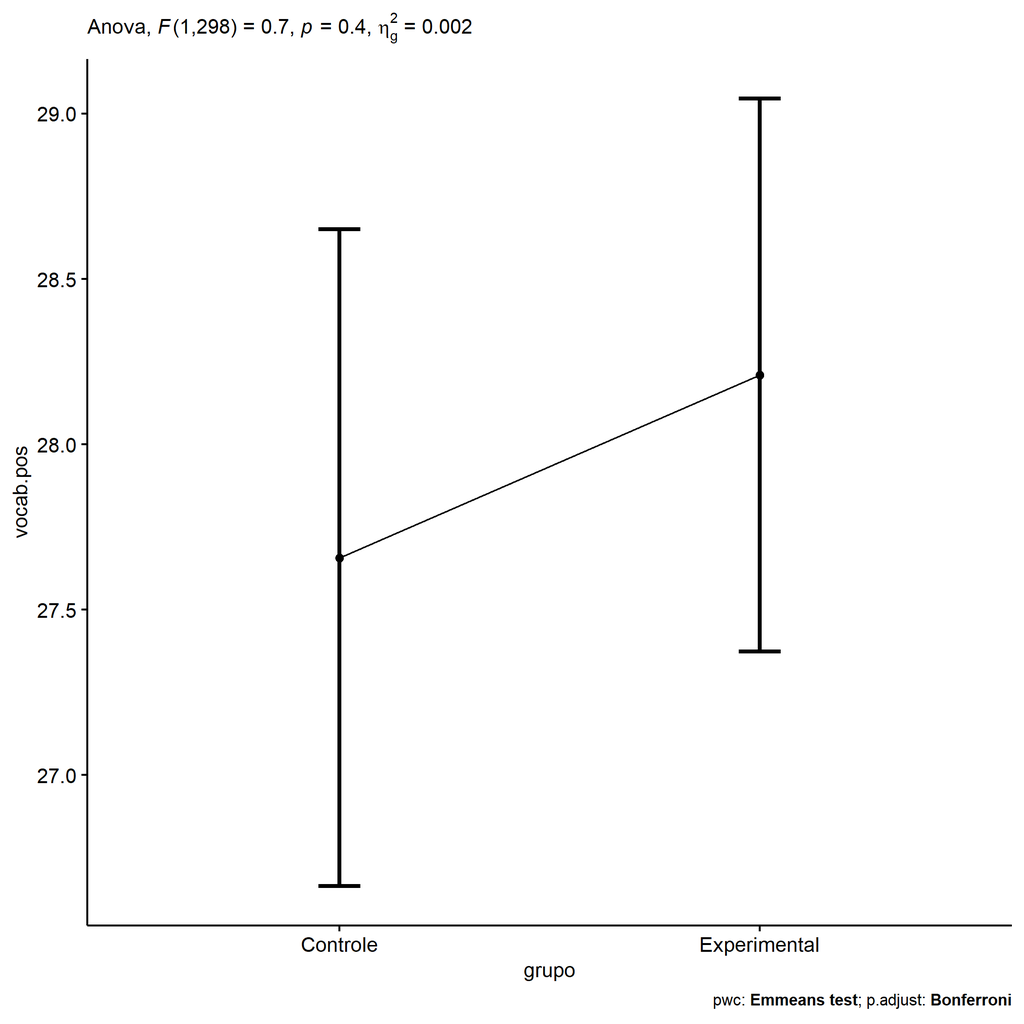

```r
if (!is.null(nrow(plots[["grupo"]]$data)))
  plots[["grupo"]] + ggplot2::scale_color_manual(values = color[["grupo"]])
```

```r
plots <- oneWayAncovaBoxPlots(
  wdat, "vocab.pos", "grupo", aov, pwc, covar = "vocab.pre",
  theme = "classic", color = color[["grupo"]],
  subtitle = which(aov$Effect == "grupo"))
```

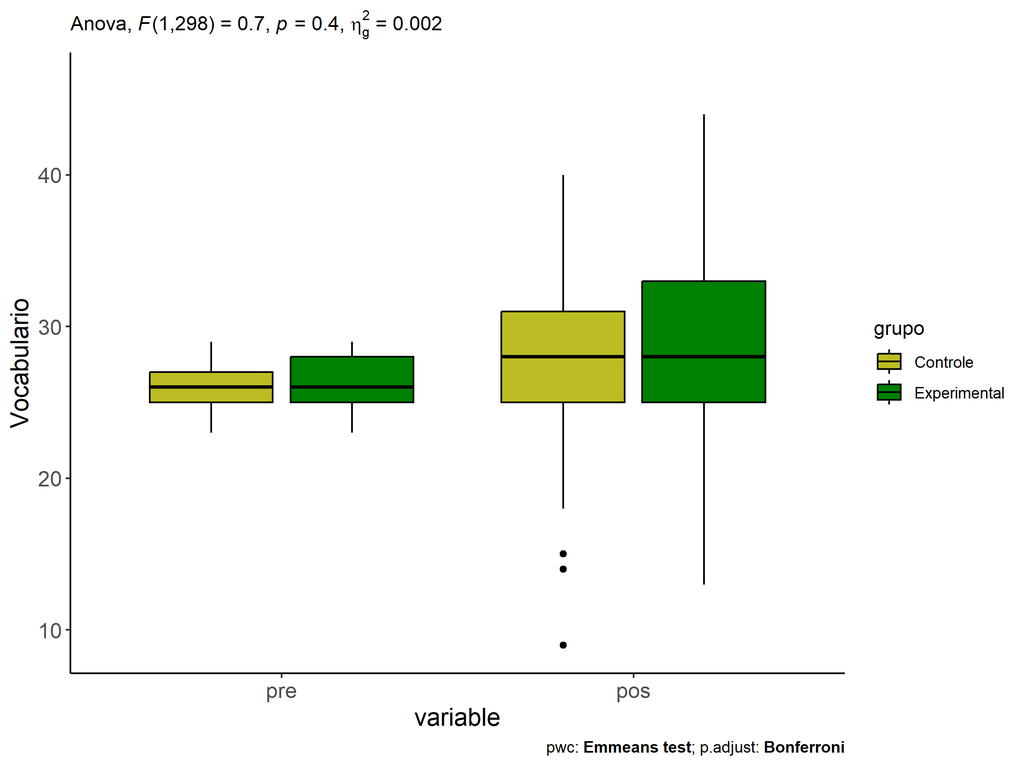

```r
if (length(unique(wdat[["grupo"]])) > 1)
  plots[["grupo"]] + ggplot2::ylab("Vocabulario") + ggplot2::scale_x_discrete(labels=c('pre', 'pos'))
```

```r
if (length(unique(wdat.long[["grupo"]])) > 1)
  plots <- oneWayAncovaBoxPlots(
    wdat.long, "vocab", "grupo", aov, pwc.long, pre.post = "time",
    theme = "classic", color = color$prepost)
```

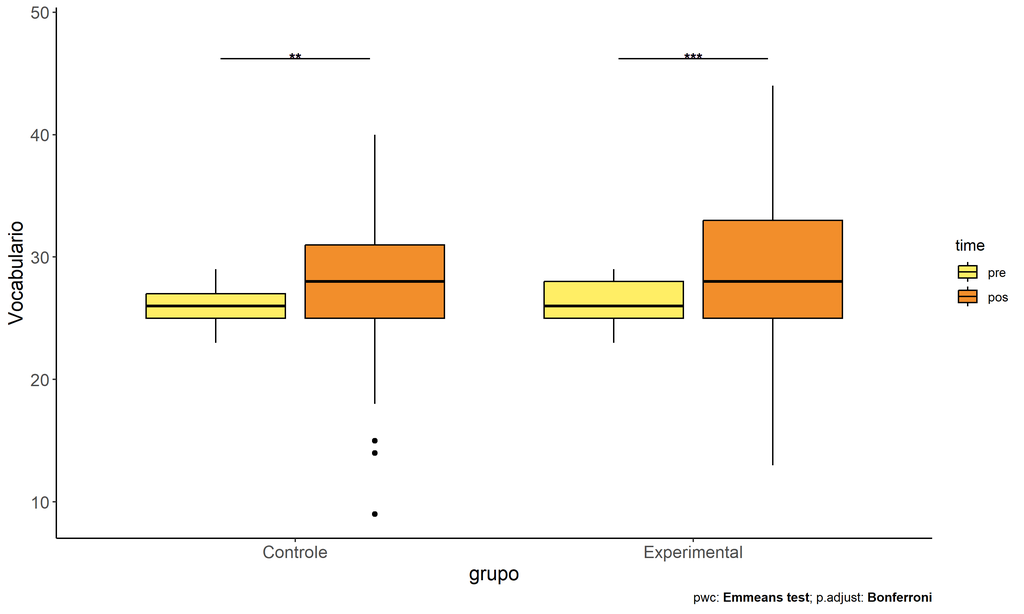

```r
if (length(unique(wdat.long[["grupo"]])) > 1)
  plots[["grupo"]] + ggplot2::ylab("Vocabulario")
```

### Checking linearity assumption

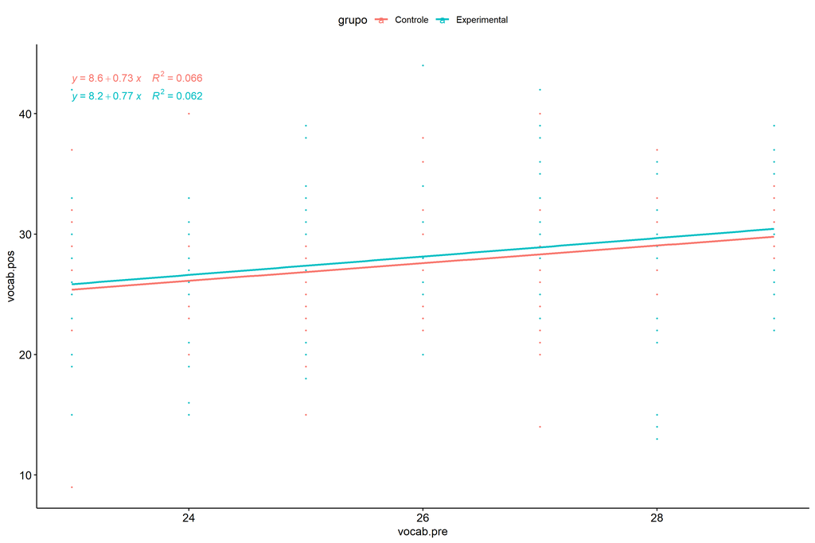

```r
ggscatter(wdat, x = "vocab.pre", y = "vocab.pos", size = 0.5,
          color = "grupo", add = "reg.line")+
  stat_regline_equation(
    aes(label =  paste(..eq.label.., ..rr.label.., sep = "~~~~"), color = grupo)
  )
```

### Checking normality and homogeneity

```r
res <- augment(lm(vocab.pos ~ vocab.pre + grupo, data = wdat))
```

```r
shapiro_test(res$.resid)
```

```
## # A tibble: 1 × 3
##   variable   statistic p.value
##   <chr>          <dbl>   <dbl>
## 1 res$.resid     0.991  0.0539
```

```r
levene_test(res, .resid ~ grupo)
```

```
## # A tibble: 1 × 4
##     df1   df2 statistic     p
##   <int> <int>     <dbl> <dbl>
## 1     1   299      2.01 0.157
```

# ANCOVA and Pairwise for two factors **grupo:Sexo**

## Without remove non-normal data

```r
pdat = remove_group_data(dat[!is.na(dat[["grupo"]]) & !is.na(dat[["Sexo"]]),], "vocab.pos", c("grupo","Sexo"))

pdat.long <- rbind(pdat[,c("id","grupo","Sexo")], pdat[,c("id","grupo","Sexo")])
pdat.long[["time"]] <- c(rep("pre", nrow(pdat)), rep("pos", nrow(pdat)))
pdat.long[["time"]] <- factor(pdat.long[["time"]], c("pre","pos"))
pdat.long[["vocab"]] <- c(pdat[["vocab.pre"]], pdat[["vocab.pos"]])

aov = anova_test(pdat, vocab.pos ~ vocab.pre + grupo*Sexo)
laov[["grupo:Sexo"]] <- get_anova_table(aov)
```

```r
pwcs <- list()
pwcs[["Sexo"]] <- emmeans_test(
  group_by(pdat, grupo), vocab.pos ~ Sexo,
  covariate = vocab.pre, p.adjust.method = "bonferroni")
pwcs[["grupo"]] <- emmeans_test(
  group_by(pdat, Sexo), vocab.pos ~ grupo,
  covariate = vocab.pre, p.adjust.method = "bonferroni")

pwc <- plyr::rbind.fill(pwcs[["grupo"]], pwcs[["Sexo"]])
pwc <- pwc[,c("grupo","Sexo", colnames(pwc)[!colnames(pwc) %in% c("grupo","Sexo")])]
```

```r
pwc.long <- emmeans_test(dplyr::group_by_at(pdat.long, c("grupo","Sexo")),
                         vocab ~ time,
                         p.adjust.method = "bonferroni")
lpwc[["grupo:Sexo"]] <- plyr::rbind.fill(pwc, pwc.long)
```

```r
ds <- get.descriptives(pdat, "vocab.pos", c("grupo","Sexo"), covar = "vocab.pre")
ds <- merge(ds[ds$variable != "vocab.pre",],
            ds[ds$variable == "vocab.pre", !colnames(ds) %in% c("variable")],
            by = c("grupo","Sexo"), all.x = T, suffixes = c("", ".vocab.pre"))
ds <- merge(get_emmeans(pwcs[["grupo"]]), ds, by = c("grupo","Sexo"), suffixes = c(".emms", ""))
ds <- ds[,c("grupo","Sexo","n","mean.vocab.pre","se.vocab.pre","mean","se","emmean","se.emms")]

colnames(ds) <- c("grupo","Sexo", "N", paste0(c("M","SE")," (pre)"),
                  paste0(c("M","SE"), " (unadj)"), paste0(c("M", "SE"), " (adj)"))

lemms[["grupo:Sexo"]] <- ds
```

## Computing ANCOVA and PairWise After removing non-normal data (OK)

```r
wdat = pdat

res = residuals(lm(vocab.pos ~ vocab.pre + grupo*Sexo, data = wdat))
non.normal = getNonNormal(res, wdat$id, plimit = 0.05)

wdat = wdat[!wdat$id %in% non.normal,]

wdat.long <- rbind(wdat[,c("id","grupo","Sexo")], wdat[,c("id","grupo","Sexo")])
wdat.long[["time"]] <- c(rep("pre", nrow(wdat)), rep("pos", nrow(wdat)))
wdat.long[["time"]] <- factor(wdat.long[["time"]], c("pre","pos"))
wdat.long[["vocab"]] <- c(wdat[["vocab.pre"]], wdat[["vocab.pos"]])


ldat[["grupo:Sexo"]] = wdat

(non.normal)
```

```
## [1] "P2192" "P2853" "P1936" "P1056" "P2251" "P3265" "P2850" "P2135" "P478"
```

```r
aov = anova_test(wdat, vocab.pos ~ vocab.pre + grupo*Sexo)
laov[["grupo:Sexo"]] <- merge(get_anova_table(aov), laov[["grupo:Sexo"]], by="Effect", suffixes = c("","'"))

(df = get_anova_table(aov))
```

```
## ANOVA Table (type II tests)
##
##       Effect DFn DFd      F        p p<.05   ges
## 1  vocab.pre   1 297 22.463 3.33e-06     * 0.070
## 2      grupo   1 297  2.023 1.56e-01       0.007
## 3       Sexo   1 297  4.270 4.00e-02     * 0.014
## 4 grupo:Sexo   1 297  0.712 4.00e-01       0.002
```

| Effect | DFn | DFd | F | p | p<.05 | ges |
| --- | --- | --- | --- | --- | --- | --- |
| vocab.pre | 1 | 297 | 22.463 | 0.000 | * | 0.070 |
| grupo | 1 | 297 | 2.023 | 0.156 |  | 0.007 |
| Sexo | 1 | 297 | 4.270 | 0.040 | * | 0.014 |
| grupo:Sexo | 1 | 297 | 0.712 | 0.400 |  | 0.002 |

```r
pwcs <- list()
pwcs[["Sexo"]] <- emmeans_test(
  group_by(wdat, grupo), vocab.pos ~ Sexo,
  covariate = vocab.pre, p.adjust.method = "bonferroni")
pwcs[["grupo"]] <- emmeans_test(
  group_by(wdat, Sexo), vocab.pos ~ grupo,
  covariate = vocab.pre, p.adjust.method = "bonferroni")

pwc <- plyr::rbind.fill(pwcs[["grupo"]], pwcs[["Sexo"]])
pwc <- pwc[,c("grupo","Sexo", colnames(pwc)[!colnames(pwc) %in% c("grupo","Sexo")])]
```

| grupo | Sexo | term | .y. | group1 | group2 | df | statistic | p | p.adj | p.adj.signif |
| --- | --- | --- | --- | --- | --- | --- | --- | --- | --- | --- |
|  | F | vocab.pre*grupo | vocab.pos | Controle | Experimental | 297 | -0.523 | 0.601 | 0.601 | ns |
|  | M | vocab.pre*grupo | vocab.pos | Controle | Experimental | 297 | -1.569 | 0.118 | 0.118 | ns |
| Controle |  | vocab.pre*Sexo | vocab.pos | F | M | 297 | 1.973 | 0.049 | 0.049 | * |
| Experimental |  | vocab.pre*Sexo | vocab.pos | F | M | 297 | 1.045 | 0.297 | 0.297 | ns |

```r
pwc.long <- emmeans_test(dplyr::group_by_at(wdat.long, c("grupo","Sexo")),
                         vocab ~ time,
                         p.adjust.method = "bonferroni")
lpwc[["grupo:Sexo"]] <- merge(plyr::rbind.fill(pwc, pwc.long), lpwc[["grupo:Sexo"]], by=c("grupo","Sexo","term",".y.","group1","group2"), suffixes = c("","'"))
```

| grupo | Sexo | term | .y. | group1 | group2 | df | statistic | p | p.adj | p.adj.signif |
| --- | --- | --- | --- | --- | --- | --- | --- | --- | --- | --- |
| Controle | F | time | vocab | pre | pos | 596 | -3.000 | 0.003 | 0.003 | ** |
| Controle | M | time | vocab | pre | pos | 596 | -0.268 | 0.788 | 0.788 | ns |
| Experimental | F | time | vocab | pre | pos | 596 | -4.061 | 0.000 | 0.000 | **** |
| Experimental | M | time | vocab | pre | pos | 596 | -2.474 | 0.014 | 0.014 | * |

```r
ds <- get.descriptives(wdat, "vocab.pos", c("grupo","Sexo"), covar = "vocab.pre")
ds <- merge(ds[ds$variable != "vocab.pre",],
            ds[ds$variable == "vocab.pre", !colnames(ds) %in% c("variable")],
            by = c("grupo","Sexo"), all.x = T, suffixes = c("", ".vocab.pre"))
ds <- merge(get_emmeans(pwcs[["grupo"]]), ds, by = c("grupo","Sexo"), suffixes = c(".emms", ""))
ds <- ds[,c("grupo","Sexo","n","mean.vocab.pre","se.vocab.pre","mean","se","emmean","se.emms")]

colnames(ds) <- c("grupo","Sexo", "N", paste0(c("M","SE")," (pre)"),
                  paste0(c("M","SE"), " (unadj)"), paste0(c("M", "SE"), " (adj)"))

lemms[["grupo:Sexo"]] <- merge(ds, lemms[["grupo:Sexo"]], by=c("grupo","Sexo"), suffixes = c("","'"))
```

| grupo | Sexo | N | M (pre) | SE (pre) | M (unadj) | SE (unadj) | M (adj) | SE (adj) |
| --- | --- | --- | --- | --- | --- | --- | --- | --- |
| Controle | F | 75 | 26.147 | 0.217 | 28.293 | 0.597 | 28.229 | 0.656 |
| Controle | M | 52 | 25.558 | 0.264 | 25.788 | 0.890 | 26.196 | 0.793 |
| Experimental | F | 94 | 26.202 | 0.203 | 28.798 | 0.594 | 28.689 | 0.587 |
| Experimental | M | 81 | 26.160 | 0.223 | 27.864 | 0.697 | 27.789 | 0.632 |

### Plots for ancova

```r
plots <- twoWayAncovaPlots(
  wdat, "vocab.pos", c("grupo","Sexo"), aov, pwcs, addParam = c("mean_se"),
  font.label.size=10, step.increase=0.05, p.label="p.adj",
  subtitle = which(aov$Effect == "grupo:Sexo"))
```

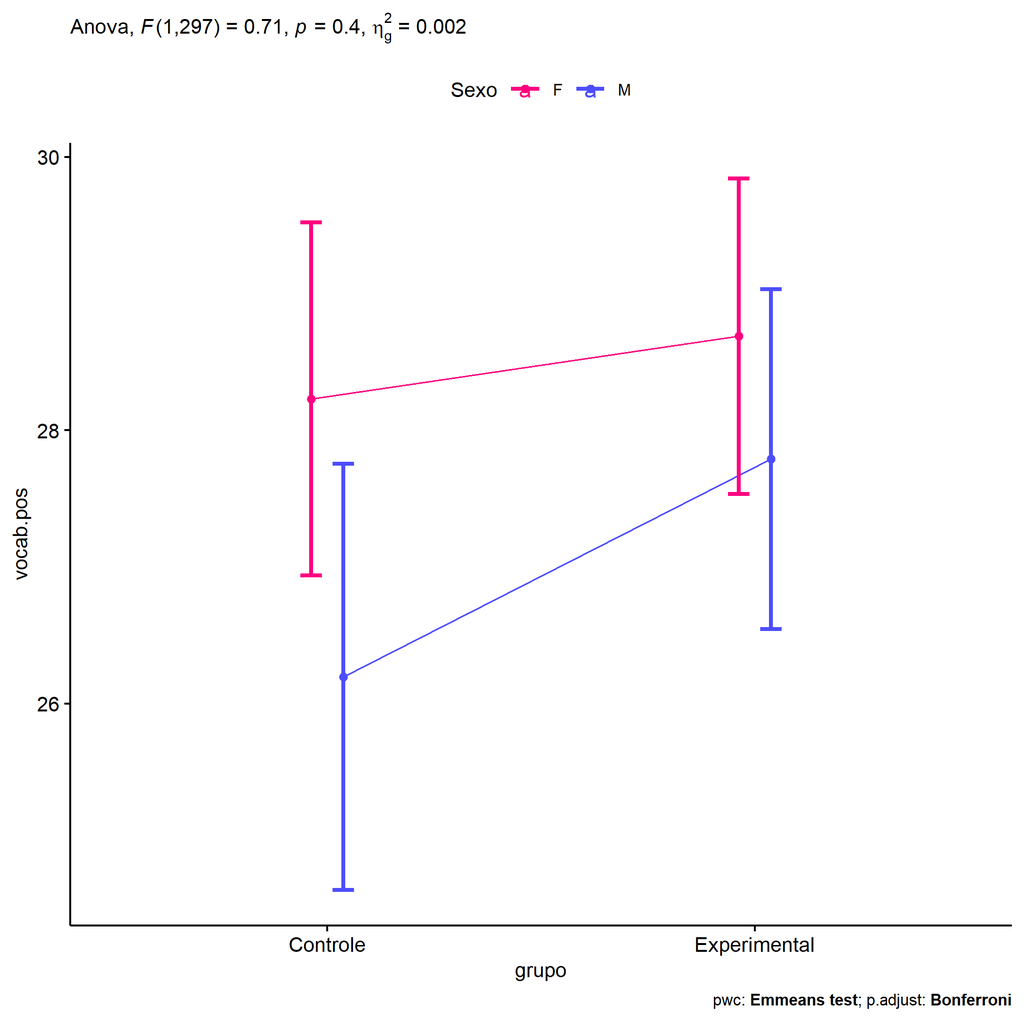

```r
if (!is.null(plots[["grupo"]]))
  plots[["grupo"]] + ggplot2::scale_color_manual(values = color[["Sexo"]])
```

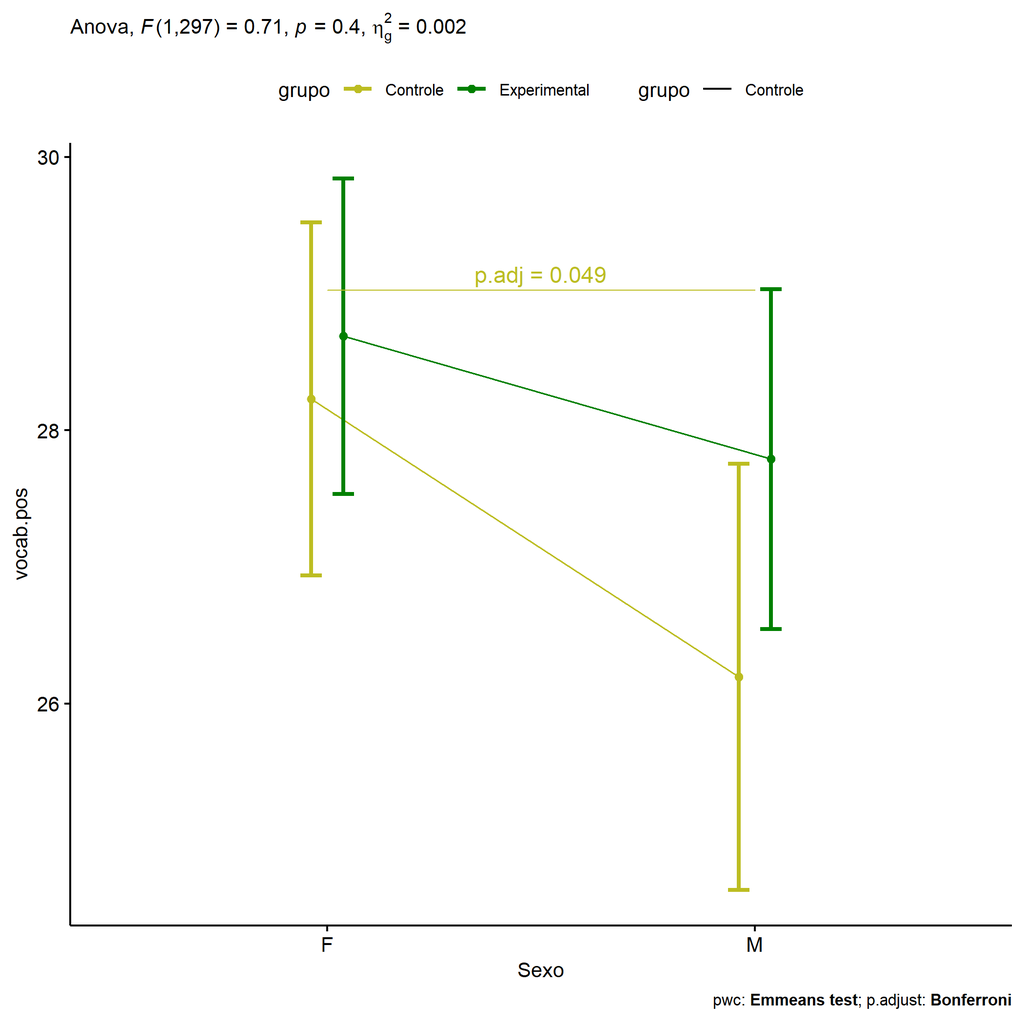

```r
if (!is.null(plots[["Sexo"]]))
  plots[["Sexo"]] + ggplot2::scale_color_manual(values = color[["grupo"]])
```

```r
plots <- twoWayAncovaBoxPlots(
  wdat, "vocab.pos", c("grupo","Sexo"), aov, pwcs, covar = "vocab.pre",
  theme = "classic", color = color[["grupo:Sexo"]],
  subtitle = which(aov$Effect == "grupo:Sexo"))
```

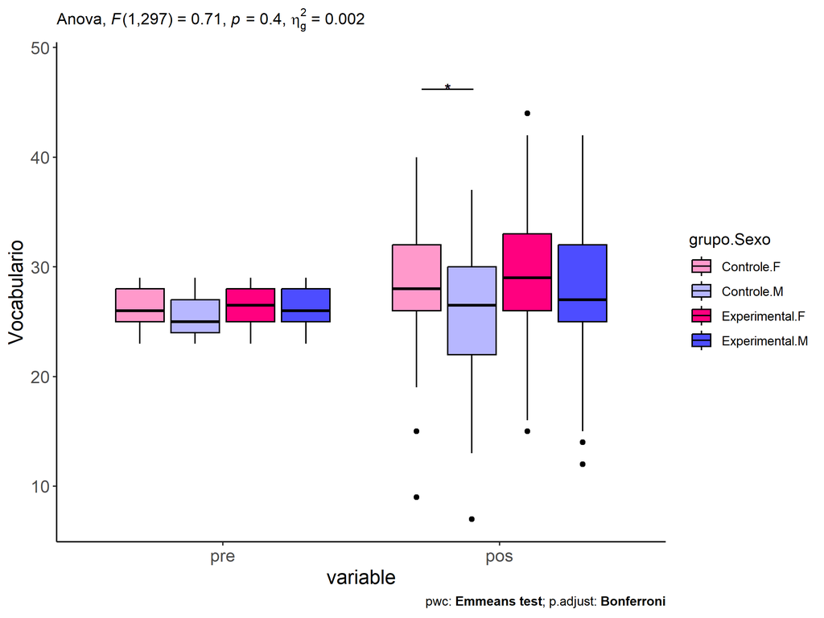

```r
plots[["grupo:Sexo"]] + ggplot2::ylab("Vocabulario") + ggplot2::scale_x_discrete(labels=c('pre', 'pos'))
```

```r
plots <- twoWayAncovaBoxPlots(
  wdat.long, "vocab", c("grupo","Sexo"), aov, pwc.long, pre.post = "time",
  theme = "classic", color = color$prepost)
```

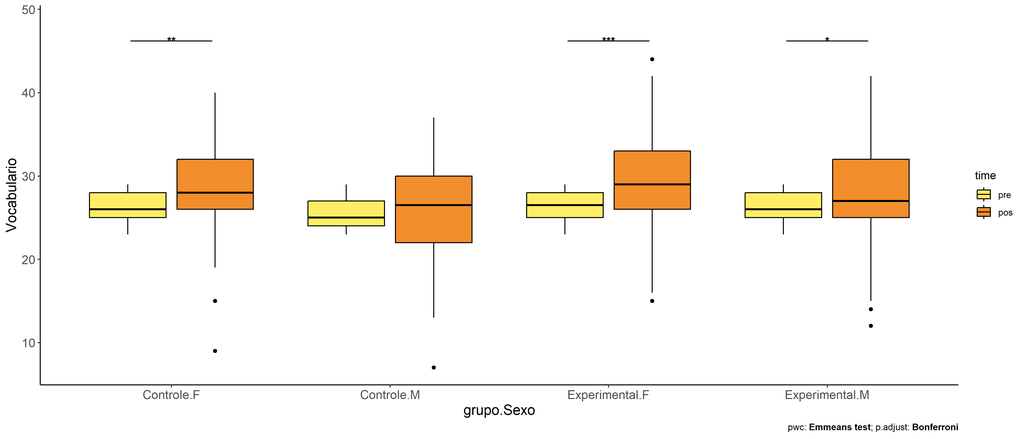

```r
plots[["grupo:Sexo"]] + ggplot2::ylab("Vocabulario")
```

### Checking linearity assumption

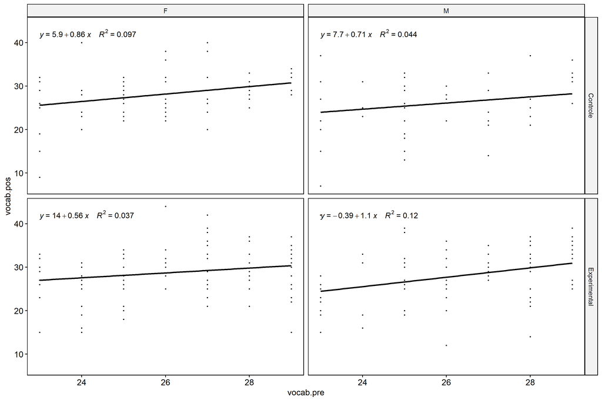

```r
ggscatter(wdat, x = "vocab.pre", y = "vocab.pos", size = 0.5,
          facet.by = c("grupo","Sexo"), add = "reg.line")+
  stat_regline_equation(
    aes(label =  paste(..eq.label.., ..rr.label.., sep = "~~~~"))
  )
```

### Checking normality and homogeneity

```r
res <- augment(lm(vocab.pos ~ vocab.pre + grupo*Sexo, data = wdat))
```

```r
shapiro_test(res$.resid)
```

```
## # A tibble: 1 × 3
##   variable   statistic p.value
##   <chr>          <dbl>   <dbl>
## 1 res$.resid     0.991  0.0591
```

```r
levene_test(res, .resid ~ grupo*Sexo)
```

```
## # A tibble: 1 × 4
##     df1   df2 statistic     p
##   <int> <int>     <dbl> <dbl>
## 1     3   298      1.17 0.320
```

# ANCOVA and Pairwise for two factors **grupo:Zona**

## Without remove non-normal data

```r
pdat = remove_group_data(dat[!is.na(dat[["grupo"]]) & !is.na(dat[["Zona"]]),], "vocab.pos", c("grupo","Zona"))

pdat.long <- rbind(pdat[,c("id","grupo","Zona")], pdat[,c("id","grupo","Zona")])
pdat.long[["time"]] <- c(rep("pre", nrow(pdat)), rep("pos", nrow(pdat)))
pdat.long[["time"]] <- factor(pdat.long[["time"]], c("pre","pos"))
pdat.long[["vocab"]] <- c(pdat[["vocab.pre"]], pdat[["vocab.pos"]])

aov = anova_test(pdat, vocab.pos ~ vocab.pre + grupo*Zona)
laov[["grupo:Zona"]] <- get_anova_table(aov)
```

```r
pwcs <- list()
pwcs[["Zona"]] <- emmeans_test(
  group_by(pdat, grupo), vocab.pos ~ Zona,
  covariate = vocab.pre, p.adjust.method = "bonferroni")
pwcs[["grupo"]] <- emmeans_test(
  group_by(pdat, Zona), vocab.pos ~ grupo,
  covariate = vocab.pre, p.adjust.method = "bonferroni")

pwc <- plyr::rbind.fill(pwcs[["grupo"]], pwcs[["Zona"]])
pwc <- pwc[,c("grupo","Zona", colnames(pwc)[!colnames(pwc) %in% c("grupo","Zona")])]
```

```r
pwc.long <- emmeans_test(dplyr::group_by_at(pdat.long, c("grupo","Zona")),
                         vocab ~ time,
                         p.adjust.method = "bonferroni")
lpwc[["grupo:Zona"]] <- plyr::rbind.fill(pwc, pwc.long)
```

```r
ds <- get.descriptives(pdat, "vocab.pos", c("grupo","Zona"), covar = "vocab.pre")
ds <- merge(ds[ds$variable != "vocab.pre",],
            ds[ds$variable == "vocab.pre", !colnames(ds) %in% c("variable")],
            by = c("grupo","Zona"), all.x = T, suffixes = c("", ".vocab.pre"))
ds <- merge(get_emmeans(pwcs[["grupo"]]), ds, by = c("grupo","Zona"), suffixes = c(".emms", ""))
ds <- ds[,c("grupo","Zona","n","mean.vocab.pre","se.vocab.pre","mean","se","emmean","se.emms")]

colnames(ds) <- c("grupo","Zona", "N", paste0(c("M","SE")," (pre)"),
                  paste0(c("M","SE"), " (unadj)"), paste0(c("M", "SE"), " (adj)"))

lemms[["grupo:Zona"]] <- ds
```

## Computing ANCOVA and PairWise After removing non-normal data (OK)

```r
wdat = pdat

res = residuals(lm(vocab.pos ~ vocab.pre + grupo*Zona, data = wdat))
non.normal = getNonNormal(res, wdat$id, plimit = 0.05)

wdat = wdat[!wdat$id %in% non.normal,]

wdat.long <- rbind(wdat[,c("id","grupo","Zona")], wdat[,c("id","grupo","Zona")])
wdat.long[["time"]] <- c(rep("pre", nrow(wdat)), rep("pos", nrow(wdat)))
wdat.long[["time"]] <- factor(wdat.long[["time"]], c("pre","pos"))
wdat.long[["vocab"]] <- c(wdat[["vocab.pre"]], wdat[["vocab.pos"]])


ldat[["grupo:Zona"]] = wdat

(non.normal)
```

```
## [1] "P1056" "P3473" "P2850" "P3042"
```

```r
aov = anova_test(wdat, vocab.pos ~ vocab.pre + grupo*Zona)
laov[["grupo:Zona"]] <- merge(get_anova_table(aov), laov[["grupo:Zona"]], by="Effect", suffixes = c("","'"))

(df = get_anova_table(aov))
```

```
## ANOVA Table (type II tests)
##
##       Effect DFn DFd          F        p p<.05      ges
## 1  vocab.pre   1 207 18.8490000 2.21e-05     * 8.30e-02
## 2      grupo   1 207  0.7280000 3.95e-01       4.00e-03
## 3       Zona   1 207  0.0000147 9.97e-01       7.10e-08
## 4 grupo:Zona   1 207  0.0005960 9.81e-01       2.88e-06
```

| Effect | DFn | DFd | F | p | p<.05 | ges |
| --- | --- | --- | --- | --- | --- | --- |
| vocab.pre | 1 | 207 | 18.849 | 0.000 | * | 0.083 |
| grupo | 1 | 207 | 0.728 | 0.395 |  | 0.004 |
| Zona | 1 | 207 | 0.000 | 0.997 |  | 0.000 |
| grupo:Zona | 1 | 207 | 0.001 | 0.981 |  | 0.000 |

```r
pwcs <- list()
pwcs[["Zona"]] <- emmeans_test(
  group_by(wdat, grupo), vocab.pos ~ Zona,
  covariate = vocab.pre, p.adjust.method = "bonferroni")
pwcs[["grupo"]] <- emmeans_test(
  group_by(wdat, Zona), vocab.pos ~ grupo,
  covariate = vocab.pre, p.adjust.method = "bonferroni")

pwc <- plyr::rbind.fill(pwcs[["grupo"]], pwcs[["Zona"]])
pwc <- pwc[,c("grupo","Zona", colnames(pwc)[!colnames(pwc) %in% c("grupo","Zona")])]
```

| grupo | Zona | term | .y. | group1 | group2 | df | statistic | p | p.adj | p.adj.signif |
| --- | --- | --- | --- | --- | --- | --- | --- | --- | --- | --- |
|  | Rural | vocab.pre*grupo | vocab.pos | Controle | Experimental | 207 | -0.726 | 0.469 | 0.469 | ns |
|  | Urbana | vocab.pre*grupo | vocab.pos | Controle | Experimental | 207 | -0.449 | 0.654 | 0.654 | ns |
| Controle |  | vocab.pre*Zona | vocab.pos | Rural | Urbana | 207 | -0.017 | 0.986 | 0.986 | ns |
| Experimental |  | vocab.pre*Zona | vocab.pos | Rural | Urbana | 207 | 0.018 | 0.986 | 0.986 | ns |

```r
pwc.long <- emmeans_test(dplyr::group_by_at(wdat.long, c("grupo","Zona")),
                         vocab ~ time,
                         p.adjust.method = "bonferroni")
lpwc[["grupo:Zona"]] <- merge(plyr::rbind.fill(pwc, pwc.long), lpwc[["grupo:Zona"]], by=c("grupo","Zona","term",".y.","group1","group2"), suffixes = c("","'"))
```

| grupo | Zona | term | .y. | group1 | group2 | df | statistic | p | p.adj | p.adj.signif |
| --- | --- | --- | --- | --- | --- | --- | --- | --- | --- | --- |
| Controle | Rural | time | vocab | pre | pos | 416 | -2.326 | 0.021 | 0.021 | * |
| Controle | Urbana | time | vocab | pre | pos | 416 | -1.267 | 0.206 | 0.206 | ns |
| Experimental | Rural | time | vocab | pre | pos | 416 | -3.250 | 0.001 | 0.001 | ** |
| Experimental | Urbana | time | vocab | pre | pos | 416 | -2.642 | 0.009 | 0.009 | ** |

```r
ds <- get.descriptives(wdat, "vocab.pos", c("grupo","Zona"), covar = "vocab.pre")
ds <- merge(ds[ds$variable != "vocab.pre",],
            ds[ds$variable == "vocab.pre", !colnames(ds) %in% c("variable")],
            by = c("grupo","Zona"), all.x = T, suffixes = c("", ".vocab.pre"))
ds <- merge(get_emmeans(pwcs[["grupo"]]), ds, by = c("grupo","Zona"), suffixes = c(".emms", ""))
ds <- ds[,c("grupo","Zona","n","mean.vocab.pre","se.vocab.pre","mean","se","emmean","se.emms")]

colnames(ds) <- c("grupo","Zona", "N", paste0(c("M","SE")," (pre)"),
                  paste0(c("M","SE"), " (unadj)"), paste0(c("M", "SE"), " (adj)"))

lemms[["grupo:Zona"]] <- merge(ds, lemms[["grupo:Zona"]], by=c("grupo","Zona"), suffixes = c("","'"))
```

| grupo | Zona | N | M (pre) | SE (pre) | M (unadj) | SE (unadj) | M (adj) | SE (adj) |
| --- | --- | --- | --- | --- | --- | --- | --- | --- |
| Controle | Rural | 69 | 25.870 | 0.233 | 27.565 | 0.690 | 27.819 | 0.666 |
| Controle | Urbana | 22 | 26.455 | 0.415 | 28.091 | 1.044 | 27.842 | 1.176 |
| Experimental | Rural | 72 | 26.236 | 0.216 | 28.556 | 0.733 | 28.495 | 0.649 |
| Experimental | Urbana | 49 | 26.347 | 0.294 | 28.633 | 0.762 | 28.476 | 0.788 |

### Plots for ancova

```r
plots <- twoWayAncovaPlots(
  wdat, "vocab.pos", c("grupo","Zona"), aov, pwcs, addParam = c("mean_se"),
  font.label.size=10, step.increase=0.05, p.label="p.adj",
  subtitle = which(aov$Effect == "grupo:Zona"))
```

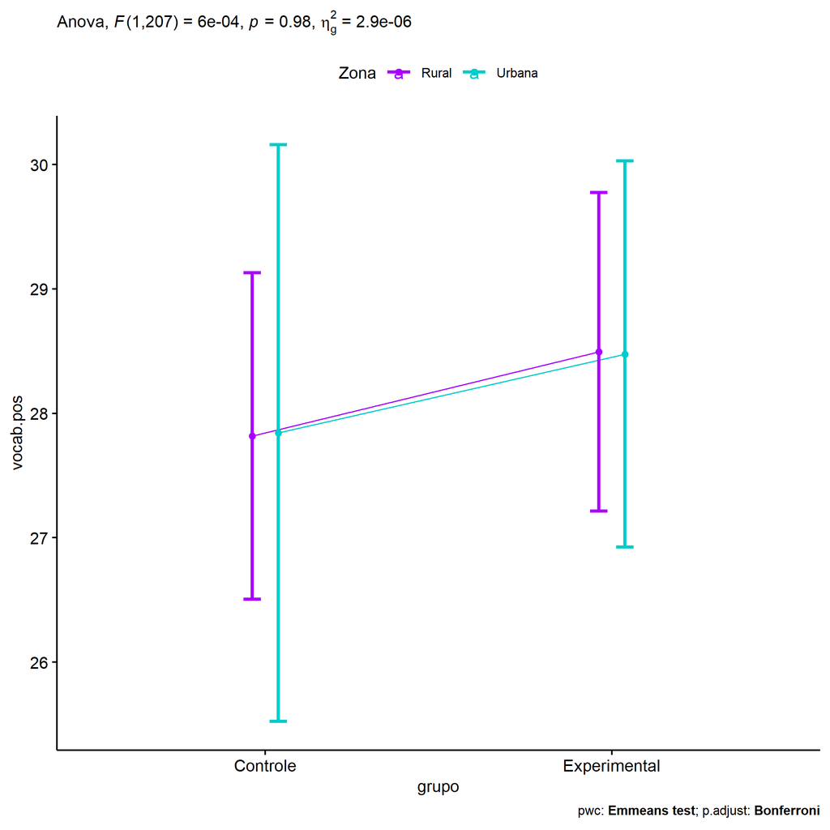

```r
if (!is.null(plots[["grupo"]]))
  plots[["grupo"]] + ggplot2::scale_color_manual(values = color[["Zona"]])
```

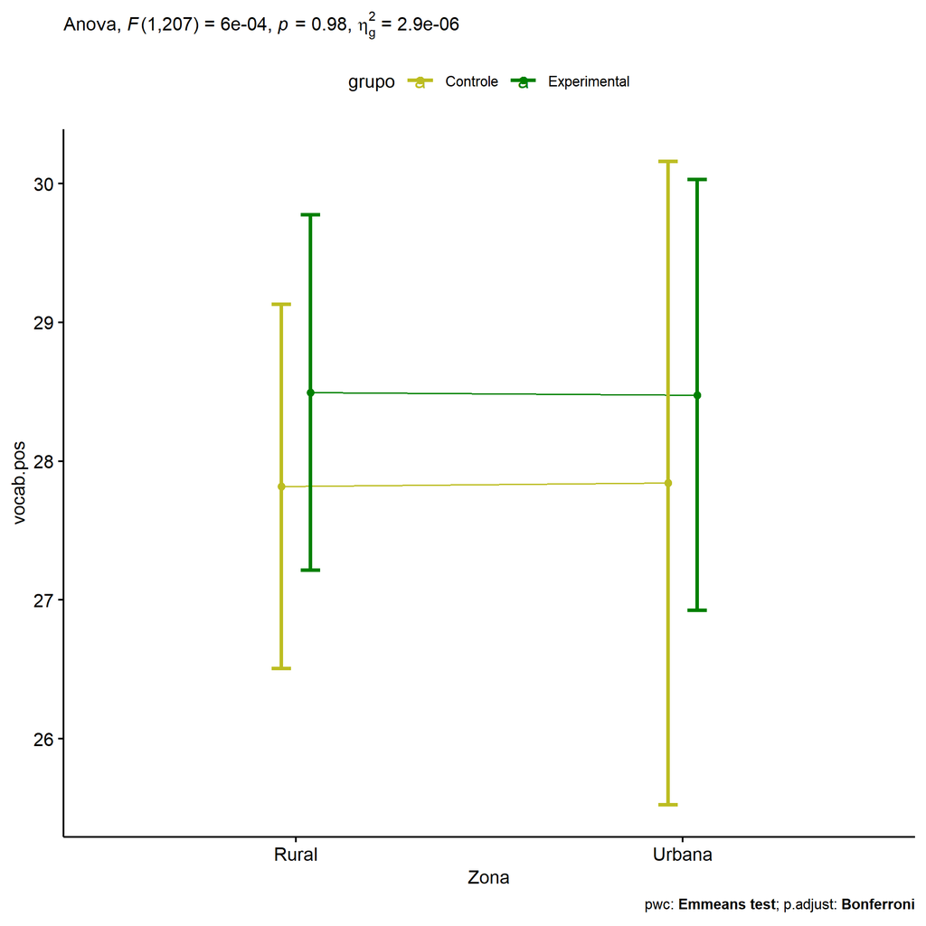

```r
if (!is.null(plots[["Zona"]]))
  plots[["Zona"]] + ggplot2::scale_color_manual(values = color[["grupo"]])
```

```r
plots <- twoWayAncovaBoxPlots(
  wdat, "vocab.pos", c("grupo","Zona"), aov, pwcs, covar = "vocab.pre",
  theme = "classic", color = color[["grupo:Zona"]],
  subtitle = which(aov$Effect == "grupo:Zona"))
```

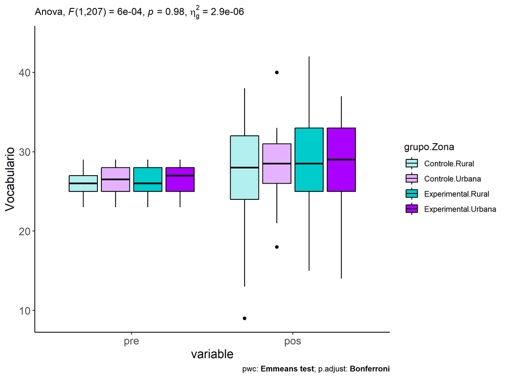

```r
plots[["grupo:Zona"]] + ggplot2::ylab("Vocabulario") + ggplot2::scale_x_discrete(labels=c('pre', 'pos'))
```

```r
plots <- twoWayAncovaBoxPlots(
  wdat.long, "vocab", c("grupo","Zona"), aov, pwc.long, pre.post = "time",
  theme = "classic", color = color$prepost)
```

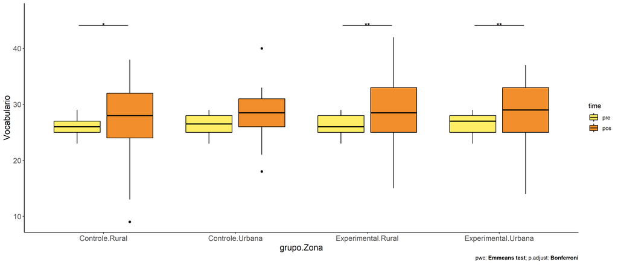

```r
plots[["grupo:Zona"]] + ggplot2::ylab("Vocabulario")
```

### Checking linearity assumption

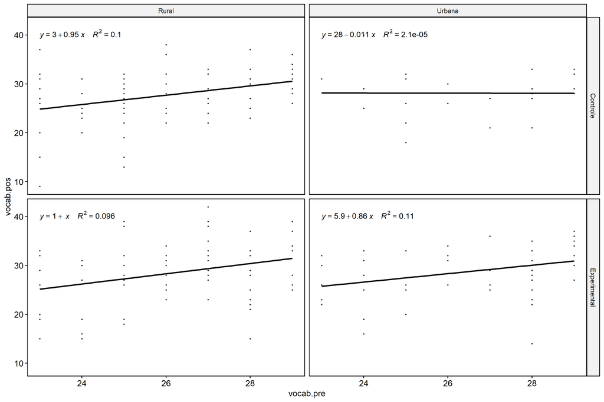

```r
ggscatter(wdat, x = "vocab.pre", y = "vocab.pos", size = 0.5,
          facet.by = c("grupo","Zona"), add = "reg.line")+
  stat_regline_equation(
    aes(label =  paste(..eq.label.., ..rr.label.., sep = "~~~~"))
  )
```

### Checking normality and homogeneity

```r
res <- augment(lm(vocab.pos ~ vocab.pre + grupo*Zona, data = wdat))
```

```r
shapiro_test(res$.resid)
```

```
## # A tibble: 1 × 3
##   variable   statistic p.value
##   <chr>          <dbl>   <dbl>
## 1 res$.resid     0.989   0.100
```

```r
levene_test(res, .resid ~ grupo*Zona)
```

```
## # A tibble: 1 × 4
##     df1   df2 statistic     p
##   <int> <int>     <dbl> <dbl>
## 1     3   208     0.818 0.485
```

# ANCOVA and Pairwise for two factors **grupo:Cor.Raca**

## Without remove non-normal data

```r
pdat = remove_group_data(dat[!is.na(dat[["grupo"]]) & !is.na(dat[["Cor.Raca"]]),], "vocab.pos", c("grupo","Cor.Raca"))
pdat.long <- rbind(pdat[,c("id","grupo","Cor.Raca")], pdat[,c("id","grupo","Cor.Raca")])
pdat.long[["time"]] <- c(rep("pre", nrow(pdat)), rep("pos", nrow(pdat)))
pdat.long[["time"]] <- factor(pdat.long[["time"]], c("pre","pos"))
pdat.long[["vocab"]] <- c(pdat[["vocab.pre"]], pdat[["vocab.pos"]])

aov = anova_test(pdat, vocab.pos ~ vocab.pre + grupo*Cor.Raca)
laov[["grupo:Cor.Raca"]] <- get_anova_table(aov)
```

```r
pwcs <- list()
pwcs[["Cor.Raca"]] <- emmeans_test(
  group_by(pdat, grupo), vocab.pos ~ Cor.Raca,
  covariate = vocab.pre, p.adjust.method = "bonferroni")
pwcs[["grupo"]] <- emmeans_test(
  group_by(pdat, Cor.Raca), vocab.pos ~ grupo,
  covariate = vocab.pre, p.adjust.method = "bonferroni")

pwc <- plyr::rbind.fill(pwcs[["grupo"]], pwcs[["Cor.Raca"]])
pwc <- pwc[,c("grupo","Cor.Raca", colnames(pwc)[!colnames(pwc) %in% c("grupo","Cor.Raca")])]
```

```r
pwc.long <- emmeans_test(dplyr::group_by_at(pdat.long, c("grupo","Cor.Raca")),
                         vocab ~ time,
                         p.adjust.method = "bonferroni")
lpwc[["grupo:Cor.Raca"]] <- plyr::rbind.fill(pwc, pwc.long)
```

```r
ds <- get.descriptives(pdat, "vocab.pos", c("grupo","Cor.Raca"), covar = "vocab.pre")
ds <- merge(ds[ds$variable != "vocab.pre",],
            ds[ds$variable == "vocab.pre", !colnames(ds) %in% c("variable")],
            by = c("grupo","Cor.Raca"), all.x = T, suffixes = c("", ".vocab.pre"))
ds <- merge(get_emmeans(pwcs[["grupo"]]), ds, by = c("grupo","Cor.Raca"), suffixes = c(".emms", ""))
ds <- ds[,c("grupo","Cor.Raca","n","mean.vocab.pre","se.vocab.pre","mean","se","emmean","se.emms")]

colnames(ds) <- c("grupo","Cor.Raca", "N", paste0(c("M","SE")," (pre)"),
                  paste0(c("M","SE"), " (unadj)"), paste0(c("M", "SE"), " (adj)"))

lemms[["grupo:Cor.Raca"]] <- ds
```

## Computing ANCOVA and PairWise After removing non-normal data (OK)

```r
wdat = pdat

res = residuals(lm(vocab.pos ~ vocab.pre + grupo*Cor.Raca, data = wdat))
non.normal = getNonNormal(res, wdat$id, plimit = 0.05)

wdat = wdat[!wdat$id %in% non.normal,]

wdat.long <- rbind(wdat[,c("id","grupo","Cor.Raca")], wdat[,c("id","grupo","Cor.Raca")])
wdat.long[["time"]] <- c(rep("pre", nrow(wdat)), rep("pos", nrow(wdat)))
wdat.long[["time"]] <- factor(wdat.long[["time"]], c("pre","pos"))
wdat.long[["vocab"]] <- c(wdat[["vocab.pre"]], wdat[["vocab.pos"]])


ldat[["grupo:Cor.Raca"]] = wdat

(non.normal)
```

[output not shown]

```r
aov = anova_test(wdat, vocab.pos ~ vocab.pre + grupo*Cor.Raca)
laov[["grupo:Cor.Raca"]] <- merge(get_anova_table(aov), laov[["grupo:Cor.Raca"]], by="Effect", suffixes = c("","'"))

(df = get_anova_table(aov))
```

```
## ANOVA Table (type II tests)
##
##           Effect DFn DFd     F     p p<.05      ges
## 1      vocab.pre   1 119 7.968 0.006     * 0.063000
## 2          grupo   1 119 0.221 0.639       0.002000
## 3       Cor.Raca   2 119 2.908 0.058       0.047000
## 4 grupo:Cor.Raca   1 119 0.069 0.793       0.000583
```

| Effect | DFn | DFd | F | p | p<.05 | ges |
| --- | --- | --- | --- | --- | --- | --- |
| vocab.pre | 1 | 119 | 7.968 | 0.006 | * | 0.063 |
| grupo | 1 | 119 | 0.221 | 0.639 |  | 0.002 |
| Cor.Raca | 2 | 119 | 2.908 | 0.058 |  | 0.047 |
| grupo:Cor.Raca | 1 | 119 | 0.069 | 0.793 |  | 0.001 |

```r
pwcs <- list()
pwcs[["Cor.Raca"]] <- emmeans_test(
  group_by(wdat, grupo), vocab.pos ~ Cor.Raca,
  covariate = vocab.pre, p.adjust.method = "bonferroni")
pwcs[["grupo"]] <- emmeans_test(
  group_by(wdat, Cor.Raca), vocab.pos ~ grupo,
  covariate = vocab.pre, p.adjust.method = "bonferroni")

pwc <- plyr::rbind.fill(pwcs[["grupo"]], pwcs[["Cor.Raca"]])
pwc <- pwc[,c("grupo","Cor.Raca", colnames(pwc)[!colnames(pwc) %in% c("grupo","Cor.Raca")])]
```

| grupo | Cor.Raca | term | .y. | group1 | group2 | df | statistic | p | p.adj | p.adj.signif |
| --- | --- | --- | --- | --- | --- | --- | --- | --- | --- | --- |
|  | Branca | vocab.pre*grupo | vocab.pos | Controle | Experimental | 119 | 0.484 | 0.629 | 0.629 | ns |
|  | Indígena | vocab.pre*grupo | vocab.pos | Controle | Experimental |  |  |  |  |  |
|  | Parda | vocab.pre*grupo | vocab.pos | Controle | Experimental | 119 | 0.238 | 0.813 | 0.813 | ns |
| Controle |  | vocab.pre*Cor.Raca | vocab.pos | Branca | Indígena | 119 | -1.421 | 0.158 | 0.474 | ns |
| Controle |  | vocab.pre*Cor.Raca | vocab.pos | Branca | Parda | 119 | -1.262 | 0.209 | 0.628 | ns |
| Controle |  | vocab.pre*Cor.Raca | vocab.pos | Indígena | Parda | 119 | 0.607 | 0.545 | 1.000 | ns |
| Experimental |  | vocab.pre*Cor.Raca | vocab.pos | Branca | Indígena |  |  |  |  |  |
| Experimental |  | vocab.pre*Cor.Raca | vocab.pos | Branca | Parda | 119 | -1.863 | 0.065 | 0.065 | ns |
| Experimental |  | vocab.pre*Cor.Raca | vocab.pos | Indígena | Parda |  |  |  |  |  |

```r
pwc.long <- emmeans_test(dplyr::group_by_at(wdat.long, c("grupo","Cor.Raca")),
                         vocab ~ time,
                         p.adjust.method = "bonferroni")
lpwc[["grupo:Cor.Raca"]] <- merge(plyr::rbind.fill(pwc, pwc.long), lpwc[["grupo:Cor.Raca"]], by=c("grupo","Cor.Raca","term",".y.","group1","group2"), suffixes = c("","'"))
```

| grupo | Cor.Raca | term | .y. | group1 | group2 | df | statistic | p | p.adj | p.adj.signif |
| --- | --- | --- | --- | --- | --- | --- | --- | --- | --- | --- |
| Controle | Branca | time | vocab | pre | pos | 240 | 0.073 | 0.942 | 0.942 | ns |
| Controle | Indígena | time | vocab | pre | pos | 240 | -1.662 | 0.098 | 0.098 | ns |
| Controle | Parda | time | vocab | pre | pos | 240 | -2.061 | 0.040 | 0.040 | * |
| Experimental | Branca | time | vocab | pre | pos | 240 | 0.783 | 0.434 | 0.434 | ns |
| Experimental | Indígena | time | vocab | pre | pos |  |  |  |  |  |
| Experimental | Parda | time | vocab | pre | pos | 240 | -1.949 | 0.052 | 0.052 | ns |

```r
ds <- get.descriptives(wdat, "vocab.pos", c("grupo","Cor.Raca"), covar = "vocab.pre")
ds <- merge(ds[ds$variable != "vocab.pre",],
            ds[ds$variable == "vocab.pre", !colnames(ds) %in% c("variable")],
            by = c("grupo","Cor.Raca"), all.x = T, suffixes = c("", ".vocab.pre"))
ds <- merge(get_emmeans(pwcs[["grupo"]]), ds, by = c("grupo","Cor.Raca"), suffixes = c(".emms", ""))
ds <- ds[,c("grupo","Cor.Raca","n","mean.vocab.pre","se.vocab.pre","mean","se","emmean","se.emms")]

colnames(ds) <- c("grupo","Cor.Raca", "N", paste0(c("M","SE")," (pre)"),
                  paste0(c("M","SE"), " (unadj)"), paste0(c("M", "SE"), " (adj)"))

lemms[["grupo:Cor.Raca"]] <- merge(ds, lemms[["grupo:Cor.Raca"]], by=c("grupo","Cor.Raca"), suffixes = c("","'"))
```

| grupo | Cor.Raca | N | M (pre) | SE (pre) | M (unadj) | SE (unadj) | M (adj) | SE (adj) |
| --- | --- | --- | --- | --- | --- | --- | --- | --- |
| Controle | Branca | 16 | 26.438 | 0.408 | 26.312 | 1.193 | 26.059 | 1.588 |
| Controle | Indígena | 8 | 25.250 | 0.773 | 29.250 | 2.051 | 29.995 | 2.258 |
| Controle | Parda | 35 | 25.971 | 0.308 | 28.343 | 1.120 | 28.481 | 1.073 |
| Experimental | Branca | 22 | 26.455 | 0.464 | 25.318 | 1.541 | 25.050 | 1.356 |
| Experimental | Parda | 44 | 26.159 | 0.298 | 28.159 | 1.013 | 28.140 | 0.956 |